# cell_line_analysis.R

kkumbier

2021-07-28

[output not shown]

# Bioactivity filtering

Before training compound classifiers, we filter out compounds/doses that cannot be distinguished from DMSO. Specifically, we (i) take a subsample of DMSO wells (ii) compute the center of the DMSO point cloud by taking average feature values across each well in the subsample (iii) compute the l2 distance between each DMSO well in the subsample and the DMSO point cloud center (iv) define the DMSO maximal distance as the maximum distance (from iii) over all subsampled wells.

We then ask whether a given well (any compound) is further from the DMSO point cloud center than the maximal DMSO distance. Repeating this process across many subsamples allows us to generate a bioactivity p-value. Tables below summarize bioactivity by plate, compound category (in reference set), and cell line.

```r
################################################################################
# Bioactivity
################################################################################
setwd('~/github/cancer_translator/')

# Normalize data matrix
l2norm <- function(z) z / sqrt(sum(z ^ 2))
x <- mutate_if(x, is.numeric, l2norm)

# Compute bioactivity scores for each well
xdist <- mclapply(unique(x$PlateID), function(p) {
  out <- filter(x, PlateID == p) %>% dplyr::select(-matches('^PC'))
  return(bioactivity(out))
}, mc.cores=n.core)

xdist <- rbindlist(xdist)

# Bioactivity by plate
bioactive.plate <- group_by(xdist, PlateID) %>%
  summarize(PropBioactive=mean(pval == 0))

print(bioactive.plate)
```

```
## # A tibble: 37 x 2
##    PlateID    PropBioactive
##    <chr>              <dbl>
##  1 2021018020         0.511
##  2 2021018021         0.345
##  3 2021018022         0.309
##  4 2021018023         0.455
##  5 2021018024         0.318
##  6 2021018025         0.212
##  7 2021018026         0.430
##  8 2021018027         0.512
##  9 2021018029         0.423
## 10 2021018030         0.140
## # … with 27 more rows
```

```r
write.csv(file='results/bioactivity_plate.csv', bioactive.plate, quote=FALSE)

# Bioactivity by compound category
bioactive.category <- filter(xdist, Compound_Usage == 'reference_cpd') %>%
  group_by(Compound_Category) %>%
  summarize(PropBioactive=mean(pval == 0))

print(bioactive.category)
```

```
## # A tibble: 10 x 2
##    Compound_Category PropBioactive
##    <chr>                     <dbl>
##  1 Actin                     0.6
##  2 AuroraB                   0.343
##  3 DNA                       0.48
##  4 ER                        0.557
##  5 HDAC                      0.474
##  6 HSP90                     0.726
##  7 MT                        0.794
##  8 mTOR                      0.686
##  9 PLK                       0.829
## 10 Proteasome                0.617
```

```r
write.csv(file='results/bioactivity_category.csv', bioactive.category, quote=FALSE)

# Bioactivity by cell line
bioactive.cell <- filter(xdist, Compound_Usage == 'reference_cpd') %>%
  group_by(Cell_Line) %>%
  summarize(PropBioactive=mean(pval == 0))

print(bioactive.cell)
```

```
## # A tibble: 3 x 2
##   Cell_Line PropBioactive
##   <chr>             <dbl>
## 1 786-0             0.646
## 2 A549              0.579
## 3 OVCAR4            0.663
```

```r
write.csv(file='results/bioactivity_category.csv', bioactive.cell, quote=FALSE)

# Bioactivity by cell line/category
bioactive.cell.cat <- filter(xdist, Compound_Usage == 'reference_cpd') %>%
  group_by(Compound_Category, Cell_Line) %>%
  summarize(PropBioactive=mean(pval == 0))
print(bioactive.cell.cat)
```

```
## # A tibble: 30 x 3
## # Groups:   Compound_Category [10]
##    Compound_Category Cell_Line PropBioactive
##    <chr>             <chr>             <dbl>
##  1 Actin             786-0             0.6
##  2 Actin             A549              0.6
##  3 Actin             OVCAR4            0.6
##  4 AuroraB           786-0             0.2
##  5 AuroraB           A549              0.4
##  6 AuroraB           OVCAR4            0.4
##  7 DNA               786-0             0.56
##  8 DNA               A549              0.427
##  9 DNA               OVCAR4            0.48
## 10 ER                786-0             0.65
## # … with 20 more rows
```

```r
write.csv(file='results/bioactivity_cell_category.csv', bioactive.cell.cat, quote=FALSE)

# Filter to reference compound doses that are bioactive in > 1 cell line
xdist.select <- filter(xdist, Compound_Usage == 'reference_cpd') %>%
  filter(pval == 0) %>%
  mutate(Compound_Dose=str_c(Compound_ID, ', ', Dose_Category))
```

# Modeling

For each cell line, we train classifiers to predict compound category from phenotypic profiling features. Compounds/doses are filtered to include only those that are bioactive in at least one cell line.

First, we assess performance relative to a random holdout set. That is, 80% of wells are randomly sampled to train models and the remaining 20% are used to assess accuracy. Note: a compound can appear in both the training and test sets but at different doses.

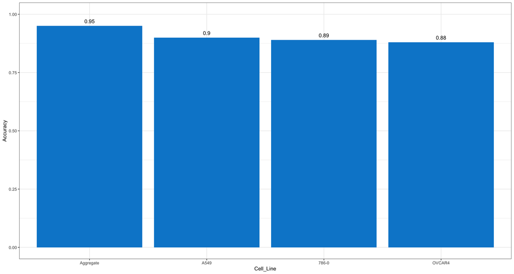

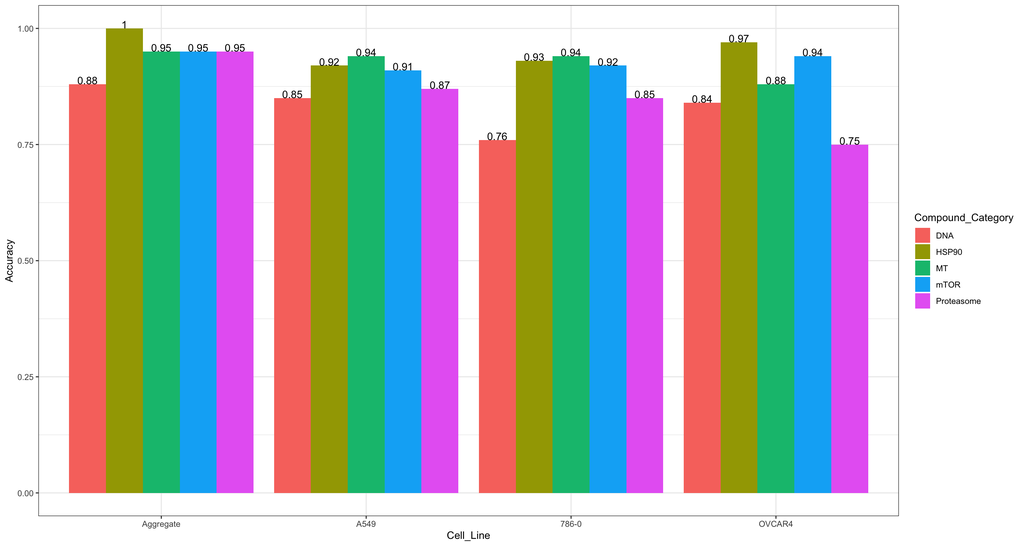

Next, we assess performance relative to a randomly held out compounds. That is, 4 compounds from each category randomly sampled to train models and the remaining compound from each category is used to assess accuracy. Note: models here are evaluated on compounds they have never seen

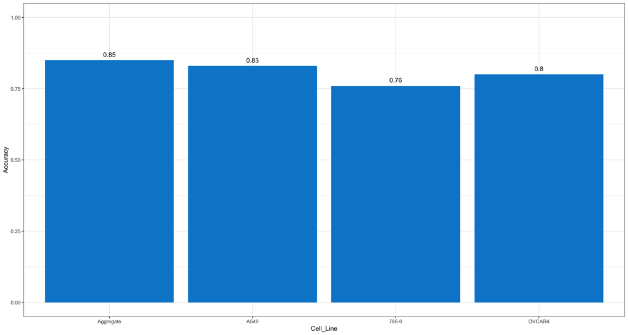

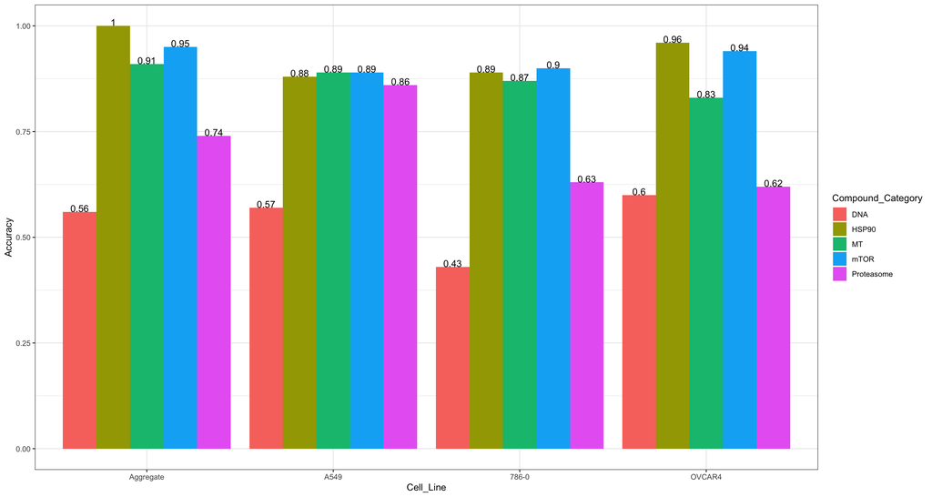